# Exploring Music Structure and Clustering in Spotify Tracks Using Unsupervised Learning

## Data Preparation

```python
# Importing Libraries
import pandas as pd
import matplotlib.pyplot as plt
import seaborn as sns
import numpy as np
from sklearn.preprocessing import LabelEncoder
from sklearn.preprocessing import StandardScaler
from sklearn.decomposition import PCA
from sklearn.cluster import KMeans
from sklearn.metrics import silhouette_score
from scipy.cluster.hierarchy import dendrogram, linkage, cut_tree
from sklearn.metrics import confusion_matrix, adjusted_rand_score
from scipy.cluster.hierarchy import dendrogram, linkage, cut_tree
from matplotlib.colors import ListedColormap
import warnings
```

```python
# Loading Dataset
spotify_df = pd.read_csv('SpotifyFeatures.csv')
```

```python
spotify_df.head(5)
```

|  | genre | artist_name | track_name | track_id | popularity | acousticness | danceability | duration_ms | energy | instrumentalness | key | liveness | loudness | mode | speechiness | tempo | time_signature | valence |
| --- | --- | --- | --- | --- | --- | --- | --- | --- | --- | --- | --- | --- | --- | --- | --- | --- | --- | --- |
| 0 | Movie | Henri Salvador | C'est beau de faire un Show | 0BRjO6ga9RKCKjfDqeFgWV | 0 | 0.611 | 0.389 | 99373 | 0.910 | 0.000 | C# | 0.3460 | -1.828 | Major | 0.0525 | 166.969 | 4/4 | 0.814 |
| 1 | Movie | Martin & les fées | Perdu d'avance (par Gad Elmaleh) | 0BjC1NfoEOOusryehmNudP | 1 | 0.246 | 0.590 | 137373 | 0.737 | 0.000 | F# | 0.1510 | -5.559 | Minor | 0.0868 | 174.003 | 4/4 | 0.816 |
| 2 | Movie | Joseph Williams | Don't Let Me Be Lonely Tonight | 0CoSDzoNIKCRs124s9uTVy | 3 | 0.952 | 0.663 | 170267 | 0.131 | 0.000 | C | 0.1030 | -13.879 | Minor | 0.0362 | 99.488 | 5/4 | 0.368 |
| 3 | Movie | Henri Salvador | Dis-moi Monsieur Gordon Cooper | 0Gc6TVm52BwZD07Ki6tIvf | 0 | 0.703 | 0.240 | 152427 | 0.326 | 0.000 | C# | 0.0985 | -12.178 | Major | 0.0395 | 171.758 | 4/4 | 0.227 |
| 4 | Movie | Fabien Nataf | Ouverture | 0IuslXpMROHdEPvSl1fTQK | 4 | 0.950 | 0.331 | 82625 | 0.225 | 0.123 | F | 0.2020 | -21.150 | Major | 0.0456 | 140.576 | 4/4 | 0.390 |

```python
# Data Exploration
# Total Rows
total_rows = len(spotify_df)
print("Total number of rows:", total_rows)
```

```
Total number of rows: 232725
```

```python
# Data Description
spotify_df.info()
spotify_df.describe()
```

```
<class 'pandas.core.frame.DataFrame'>
RangeIndex: 232725 entries, 0 to 232724
Data columns (total 18 columns):
 #   Column            Non-Null Count   Dtype
---  ------            --------------   -----
 0   genre             232725 non-null  object
 1   artist_name       232725 non-null  object
 2   track_name        232724 non-null  object
 3   track_id          232725 non-null  object
 4   popularity        232725 non-null  int64
 5   acousticness      232725 non-null  float64
 6   danceability      232725 non-null  float64
 7   duration_ms       232725 non-null  int64
 8   energy            232725 non-null  float64
 9   instrumentalness  232725 non-null  float64
 10  key               232725 non-null  object
 11  liveness          232725 non-null  float64
 12  loudness          232725 non-null  float64
 13  mode              232725 non-null  object
 14  speechiness       232725 non-null  float64
 15  tempo             232725 non-null  float64
 16  time_signature    232725 non-null  object
 17  valence           232725 non-null  float64
dtypes: float64(9), int64(2), object(7)
memory usage: 32.0+ MB
```

|  | popularity | acousticness | danceability | duration_ms | energy | instrumentalness | liveness | loudness | speechiness | tempo | valence |
| --- | --- | --- | --- | --- | --- | --- | --- | --- | --- | --- | --- |
| count | 232725.000000 | 232725.000000 | 232725.000000 | 2.327250e+05 | 232725.000000 | 232725.000000 | 232725.000000 | 232725.000000 | 232725.000000 | 232725.000000 | 232725.000000 |
| mean | 41.127502 | 0.368560 | 0.554364 | 2.351223e+05 | 0.570958 | 0.148301 | 0.215009 | -9.569885 | 0.120765 | 117.666585 | 0.454917 |
| std | 18.189948 | 0.354768 | 0.185608 | 1.189359e+05 | 0.263456 | 0.302768 | 0.198273 | 5.998204 | 0.185518 | 30.898907 | 0.260065 |
| min | 0.000000 | 0.000000 | 0.056900 | 1.538700e+04 | 0.000020 | 0.000000 | 0.009670 | -52.457000 | 0.022200 | 30.379000 | 0.000000 |
| 25% | 29.000000 | 0.037600 | 0.435000 | 1.828570e+05 | 0.385000 | 0.000000 | 0.097400 | -11.771000 | 0.036700 | 92.959000 | 0.237000 |
| 50% | 43.000000 | 0.232000 | 0.571000 | 2.204270e+05 | 0.605000 | 0.000044 | 0.128000 | -7.762000 | 0.050100 | 115.778000 | 0.444000 |
| 75% | 55.000000 | 0.722000 | 0.692000 | 2.657680e+05 | 0.787000 | 0.035800 | 0.264000 | -5.501000 | 0.105000 | 139.054000 | 0.660000 |
| max | 100.000000 | 0.996000 | 0.989000 | 5.552917e+06 | 0.999000 | 0.999000 | 1.000000 | 3.744000 | 0.967000 | 242.903000 | 1.000000 |

```python
# Unique Features
print("Number of unique genres:", spotify_df['genre'].nunique())
print("Number of unique artist names:", spotify_df['artist_name'].nunique())
print("Number of unique track IDs:", spotify_df['track_id'].nunique())
```

```
Number of unique genres: 27
Number of unique artist names: 14564
Number of unique track IDs: 176774
```

```python
# Duplicate Track ID count
count = spotify_df['track_id'].value_counts()
num_duplicated_ids = (count > 1).sum()
print("Number of unique track ID values that are duplicated:", num_duplicated_ids)
```

```
Number of unique track ID values that are duplicated: 35124
```

```python
# Inspect a Duplicated Track
first_duplicate_id = spotify_df[spotify_df.duplicated(subset='track_id', keep='first')]['track_id'].iloc[0]
print("First duplicated track_id:", first_duplicate_id)
spotify_df[spotify_df['track_id'] == first_duplicate_id]
```

```
First duplicated track_id: 6iOvnACn4ChlAw4lWUU4dd
```

|  | genre | artist_name | track_name | track_id | popularity | acousticness | danceability | duration_ms | energy | instrumentalness | key | liveness | loudness | mode | speechiness | tempo | time_signature | valence |
| --- | --- | --- | --- | --- | --- | --- | --- | --- | --- | --- | --- | --- | --- | --- | --- | --- | --- | --- |
| 257 | R&B | Doja Cat | Go To Town | 6iOvnACn4ChlAw4lWUU4dd | 64 | 0.0716 | 0.71 | 217813 | 0.71 | 0.000001 | C | 0.206 | -2.474 | Major | 0.0579 | 169.944 | 4/4 | 0.7 |
| 1348 | Alternative | Doja Cat | Go To Town | 6iOvnACn4ChlAw4lWUU4dd | 64 | 0.0716 | 0.71 | 217813 | 0.71 | 0.000001 | C | 0.206 | -2.474 | Major | 0.0579 | 169.944 | 4/4 | 0.7 |
| 77710 | Children’s Music | Doja Cat | Go To Town | 6iOvnACn4ChlAw4lWUU4dd | 64 | 0.0716 | 0.71 | 217813 | 0.71 | 0.000001 | C | 0.206 | -2.474 | Major | 0.0579 | 169.944 | 4/4 | 0.7 |
| 93651 | Indie | Doja Cat | Go To Town | 6iOvnACn4ChlAw4lWUU4dd | 64 | 0.0716 | 0.71 | 217813 | 0.71 | 0.000001 | C | 0.206 | -2.474 | Major | 0.0579 | 169.944 | 4/4 | 0.7 |
| 113770 | Pop | Doja Cat | Go To Town | 6iOvnACn4ChlAw4lWUU4dd | 64 | 0.0716 | 0.71 | 217813 | 0.71 | 0.000001 | C | 0.206 | -2.474 | Major | 0.0579 | 169.944 | 4/4 | 0.7 |

```python
# Clean duplicated Tracks
spotify_df= spotify_df.drop_duplicates(subset=['track_id'])
count = spotify_df['track_id'].value_counts()
num_duplicated_ids = (count > 1).sum()
print("Number of unique tracks that are duplicated after cleaning:", num_duplicated_ids)
```

```
Number of unique tracks that are duplicated after cleaning: 0
```

```python
# Strip Leading/Trailing Whitespace and Fix Case
spotify_df['genre'] = spotify_df['genre'].str.replace('’', "'", regex=False)
spotify_df['genre'].unique()
```

```
array(['Movie', 'R&B', 'A Capella', 'Alternative', 'Country', 'Dance',
       'Electronic', 'Anime', 'Folk', 'Blues', 'Opera', 'Hip-Hop',
       "Children's Music", 'Rap', 'Indie', 'Classical', 'Pop', 'Reggae',
       'Reggaeton', 'Jazz', 'Rock', 'Ska', 'Comedy', 'Soul', 'Soundtrack',
       'World'], dtype=object)
```

## EDA

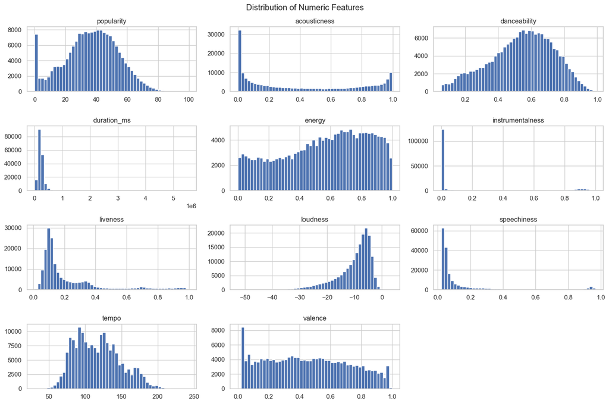

```python
# Data Visualisation
sns.set(style='whitegrid')

# Select Numeric Columns
df_numeric = spotify_df.select_dtypes(include='number')

# Plot Histograms
df_numeric.hist(bins=50, figsize=(15, 10))
plt.suptitle('Distribution of Numeric Features')
plt.tight_layout()
plt.show()
```

- As we can see time, instrumentalness and speechiness are highly skewed, it requires transformation before scaling it to reduce variance.

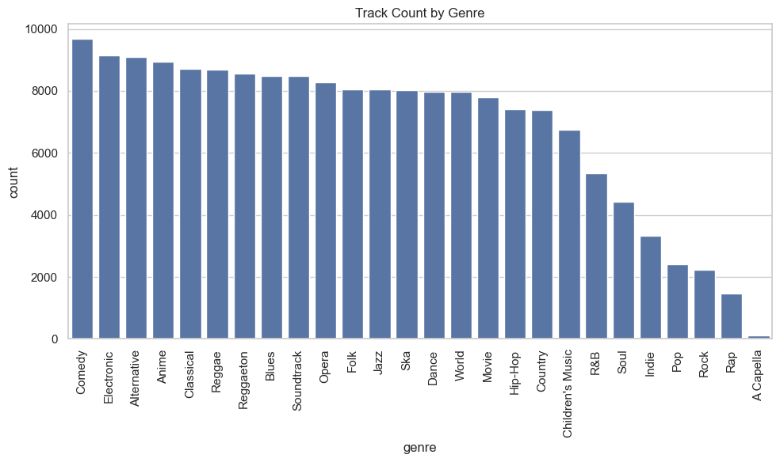

```python
# Genre Distribution
sns.set(style="whitegrid")
plt.figure(figsize=(10, 6))
sns.countplot(x='genre', data=spotify_df, order=spotify_df['genre'].value_counts().index)
plt.title('Track Count by Genre')
plt.xticks(rotation=90)
plt.tight_layout()
plt.show()
```

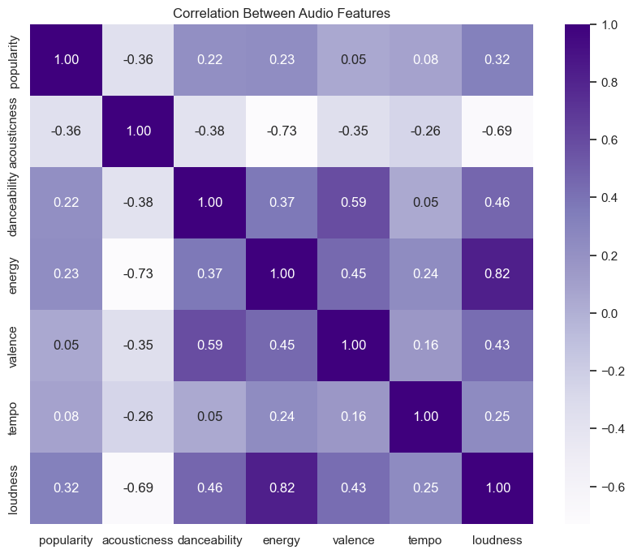

```python
# Correlation Heatmap
plt.figure(figsize=(10, 8))
features = ['popularity', 'acousticness', 'danceability', 'energy', 'valence', 'tempo', 'loudness']
corr = spotify_df[features].corr()
sns.heatmap(corr, annot=True, cmap='Purples', fmt=".2f")
plt.title('Correlation Between Audio Features')
plt.show()
```

- As we can see from above plot, popularity is weekly correlated with other musical features and hence it is not highlt correlated.
- While, energy and acoustiness are negatively correalted and loudness is positively correlated with energy.

## Data Transformation

```python
# Log Transformation
spotify_df['duration_ms'] = np.log1p(spotify_df['duration_ms'])
spotify_df['instrumentalness'] = np.log1p(spotify_df['instrumentalness'])
spotify_df['speechiness'] = np.log1p(spotify_df['speechiness'])

# Encode Categorical Data
for col in ['key', 'mode', 'time_signature']:
    le = LabelEncoder()
    spotify_df[col] = le.fit_transform(spotify_df[col])

#Drop Columns
spotify_df_cleaned = spotify_df.drop(columns=['track_id', 'artist_name', 'track_name'])

features = ['popularity', 'acousticness', 'danceability', 'duration_ms', 'energy',
            'instrumentalness', 'liveness', 'loudness', 'speechiness', 'tempo',
            'valence']

# Scale features
scaler = StandardScaler()
spotify_scaled = scaler.fit_transform(spotify_df_cleaned[features])

# Create DataFrame
spotify_scaled_df = pd.DataFrame(spotify_scaled, columns=features)
```

### Method-1:Principal Component Analysis

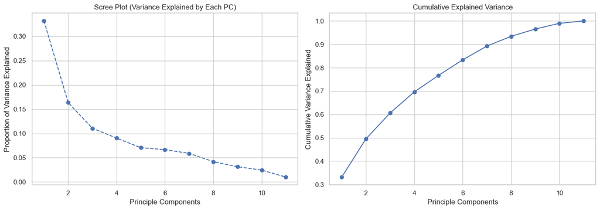

```python
# Performing PCA
pca = PCA()
spotify_pca = pca.fit_transform(spotify_scaled_df)

# Proportion of Variance Explained by Each Component
explained_variance = pca.explained_variance_ratio_

# Cumulative Variance Explained
cumulative_variance = np.cumsum(explained_variance)

# Plots
fig, axs = plt.subplots(1, 2, figsize=(14, 5))

axs[0].plot(range(1, len(explained_variance)+1), explained_variance, marker='o', linestyle='--')
axs[0].set_title("Scree Plot (Variance Explained by Each PC)")
axs[0].set_xlabel("Principle Components")
axs[0].set_ylabel("Proportion of Variance Explained")
axs[0].grid(True)

axs[1].plot(range(1, len(cumulative_variance)+1), cumulative_variance, marker='o', linestyle='-')
axs[1].set_title("Cumulative Explained Variance")
axs[1].set_xlabel("Principle Components")
axs[1].set_ylabel("Cumulative Variance Explained")
axs[1].grid(True)

plt.tight_layout()
plt.show()
```

#### Compare the PC1-PC2 scatter plot with a scatter of two original features (for example, energy vs. danceability) and provide interpretation.

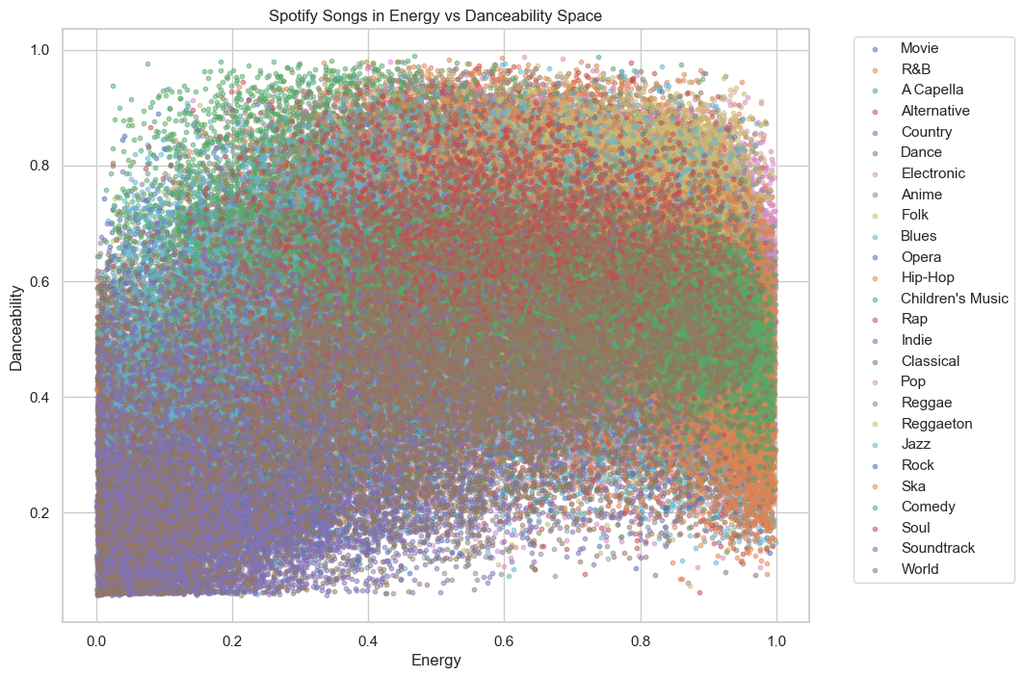

```python
plt.figure(figsize=(10, 8))
for genre in spotify_df['genre'].unique():
    subset = spotify_df[spotify_df['genre'] == genre]
    plt.scatter(subset['energy'], subset['danceability'], label=genre, alpha=0.5, s=10)
plt.title('Spotify Songs in Energy vs Danceability Space')
plt.xlabel('Energy')
plt.ylabel('Danceability')
plt.legend(bbox_to_anchor=(1.05, 1), loc='upper left')
plt.grid(True)
plt.show()
```

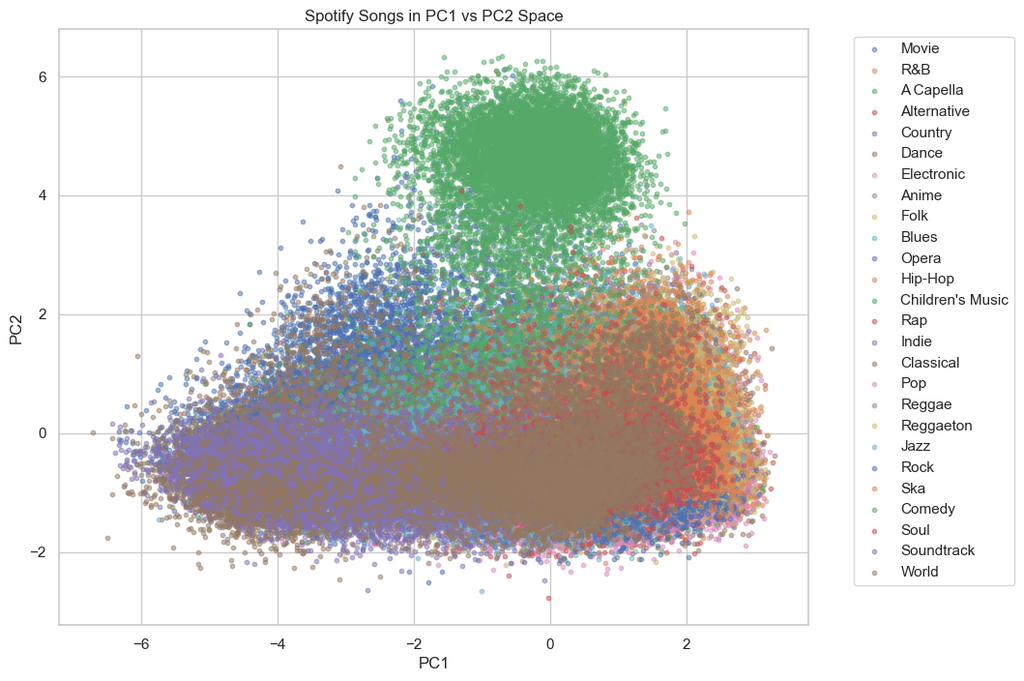

```python
# DataFrame for PCA results with PC1, PC2, and Genre
spotify_pca_df = pd.DataFrame(spotify_pca[:, :2], columns=['PC1', 'PC2'])
spotify_pca_df['genre'] = spotify_df['genre'].values  # Include genre for color coding

# Plot PC1 vs PC2 with Genre Colors
plt.figure(figsize=(10, 8))
for genre in spotify_pca_df['genre'].unique():
    subset = spotify_pca_df[spotify_pca_df['genre'] == genre]
    plt.scatter(subset['PC1'], subset['PC2'], label=genre, alpha=0.5, s=10)
plt.title('Spotify Songs in PC1 vs PC2 Space')
plt.xlabel('PC1')
plt.ylabel('PC2')
plt.legend(bbox_to_anchor=(1.05, 1), loc='upper left')
plt.grid(True)
plt.show()
```

Spotify Songs in PC1 vs PC2 Space When we mapped Spotify’s entire music catalog into PCA space, something amazing happened. Suddenly, thousands of songs—each with their unique rhythm and energy—compressed into a neat, two-dimensional scatterplot. Here, each point represents a song, blending a cocktail of features like energy, danceability, valence, and more.

What’s striking is how some genres (shown by clusters of similar colors) seem to gravitate toward each other. It’s as if PCA exposes invisible musical friendships, revealing which genres share common audio traits. Compared to the messy overlaps of the original features, this PCA view gives a much clearer picture of Spotify’s musical landscape.

Spotify Songs in Energy vs Danceability Space Now, when we look at a plot based solely on energy and danceability, the story changes. Sure, these two features tell us a lot about mood and movement, but the overall spread is much more uniform. Genres blend together here, making it harder to distinguish one from another.

It’s a reminder that while these features are important, they’re just two threads in the rich tapestry of musical characteristics. Many nuances—like tempo, loudness, or valence—get lost when we focus on only two features.

### Method-2: K-means Clustering

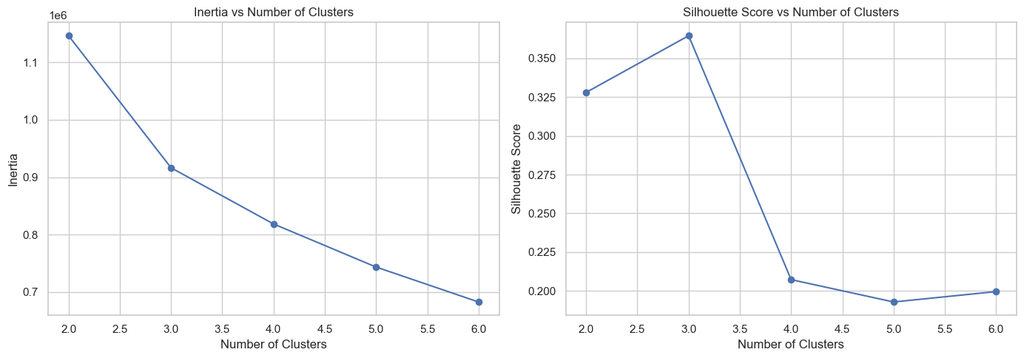

```python
# Performing K-Means
inertias = []
silhouette_scores = []
k_range = range(2, 7)

for k in k_range:
    kmeans = KMeans(n_clusters=k, random_state=42, max_iter=100, n_init=5)
    kmeans.fit(spotify_pca[:, :6])
    inertias.append(kmeans.inertia_)
    silhouette_scores.append(silhouette_score(spotify_pca[:, :6], kmeans.labels_))

# Plots
fig, axs = plt.subplots(1, 2, figsize=(14, 5))

axs[0].plot(k_range, inertias, marker='o')
axs[0].set_title('Inertia vs Number of Clusters')
axs[0].set_xlabel('Number of Clusters')
axs[0].set_ylabel('Inertia')
axs[0].grid(True)

axs[1].plot(k_range, silhouette_scores, marker='o')
axs[1].set_title('Silhouette Score vs Number of Clusters')
axs[1].set_xlabel('Number of Clusters')
axs[1].set_ylabel('Silhouette Score')
axs[1].grid(True)

plt.tight_layout()
plt.show()
```

These two plots help decide the best number of clusters for KMeans on Spotify track data. The left plot shows inertia, which measures how tightly the data points fit within their clusters, lower is better. There's a noticeable drop until 3 clusters, after which the improvement slows, suggesting 3 might be a good choice. The right plot shows the silhouette score, which measures how well-separated the clusters are. The highest score is also at 3 clusters, confirming it's likely the optimal number for this dataset.

```python
# Apply KMeans on PC1 and PC2
kmeans = KMeans(n_clusters=3, random_state=42)
spotify_df['cluster'] = kmeans.fit_predict(spotify_pca[:, [0, 1]])
```

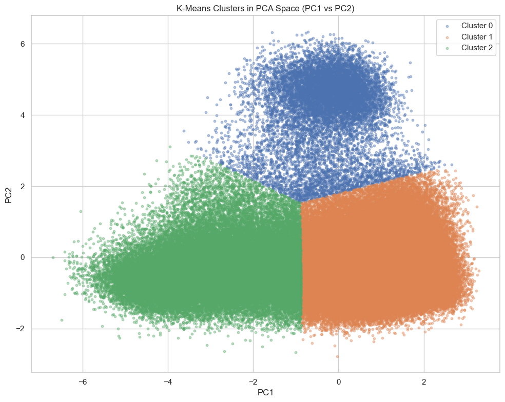

```python
plt.figure(figsize=(10, 8))

for cluster in range(3):
    idx = spotify_df['cluster'] == cluster
    plt.scatter(spotify_pca[idx, 0], spotify_pca[idx, 1], label=f'Cluster {cluster}', s=10, alpha=0.4)

plt.title('K-Means Clusters in PCA Space (PC1 vs PC2)')
plt.xlabel('PC1')
plt.ylabel('PC2')
plt.legend()
plt.grid(True)
plt.tight_layout()
plt.show()
```

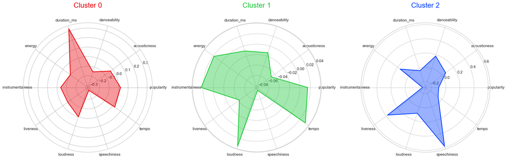

```python
colors = ['#e8000b', '#1ac938', '#023eff']

# Standardize the data (excluding the cluster column)
#scaler = StandardScaler()
df_standardized = spotify_df.copy()

# Create a new dataframe with standardized values and add the cluster column back
df_standardized = pd.DataFrame(spotify_scaled_df, columns=spotify_scaled_df.columns[:-1], index=spotify_scaled_df.index)
df_standardized['cluster'] = spotify_df['cluster']
# Calculate the centroids of each cluster
cluster_centroids = df_standardized.groupby('cluster').mean()

# Function to create a radar chart
def create_radar_chart(ax, angles, data, color, cluster):
    # Plot the data and fill the area
    ax.fill(angles, data, color=color, alpha=0.4)
    ax.plot(angles, data, color=color, linewidth=2, linestyle='solid')

    # Add a title
    ax.set_title(f'Cluster {cluster}', size=20, color=color, y=1.1)

# Set data
labels=np.array(cluster_centroids.columns)
num_vars = len(labels)

# Compute angle of each axis
angles = np.linspace(0, 2 * np.pi, num_vars, endpoint=False).tolist()

# The plot is circular, so we need to "complete the loop" and append the start to the end
labels = np.concatenate((labels, [labels[0]]))
angles += angles[:1]

# Initialize the figure
fig, ax = plt.subplots(figsize=(20, 10), subplot_kw=dict(polar=True), nrows=1, ncols=3)

# Create radar chart for each cluster
for i, color in enumerate(colors):
    data = cluster_centroids.loc[i].tolist()
    data += data[:1]  # Complete the loop
    create_radar_chart(ax[i], angles, data, color, i)

# Add input data
ax[0].set_xticks(angles[:-1])
ax[0].set_xticklabels(labels[:-1])

ax[1].set_xticks(angles[:-1])
ax[1].set_xticklabels(labels[:-1])

ax[2].set_xticks(angles[:-1])
ax[2].set_xticklabels(labels[:-1])

# Add a grid
ax[0].grid(color='grey', linewidth=0.5)

# Display the plot
plt.tight_layout()
plt.show()
```

These radar charts show the characteristics of each of the three clusters found in the Spotify track dataset using KMeans.